# MALASPINA SRF | 16S amplicons | Bacteria

Logares R. & Rubinat-Ripoll L.

24.01.2015

# 1) Data overview

Samples with less than 5000 reads are removed:

```
## MD2304 MD2332 MD2695 MD2926
##   2695   3370    411    602
```

Table dimensions and content outline:

```
## [1] 1178  119
```

```
##          MD1013 MD1035 MD1042 MD1080 MD1100
## OTU_5       162    238    486   1639    653
## OTU_1     13804   9239  37085  24192  36066
## OTU_596      20     75    100    502    118
## OTU_1295      1      1      7      1      0
## OTU_36       59    196    210    346     33
```

Minimum number of reads per station:

```r
min(colSums(otu_tb16_min5000_v2))
```

```
## [1] 5724
```

Maximum number of reads per station:

```r
max(colSums(otu_tb16_min5000_v2))
```

```
## [1] 155539
```

Identification of station with higher number of reads:

```r
amplicons_per_sample<-colSums(otu_tb16_min5000_v2)
amplicons_per_sample[which(colSums(otu_tb16_min5000_v2)>155000)]
```

```
##  MD897
## 155539
```

Overall reads per sample:

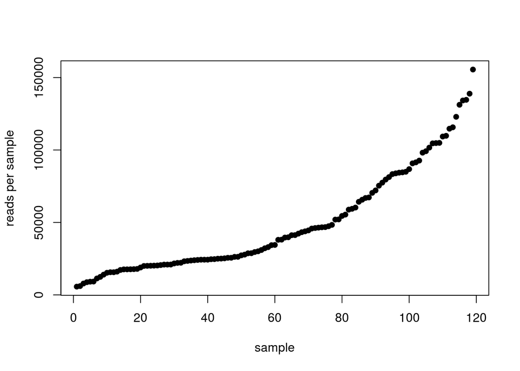

# 2) Normalization to 5000 reads per sample

Let’s normalize the original dataset by randomly subsampling 5000 reads in each station:

```r
library(vegan)
otu_tb16_min5000_v2_t<-t(otu_tb16_min5000_v2)
otu_tb16_t_ss5000<-rrarefy(otu_tb16_min5000_v2_t, 5000)
```

The normalized table shows the following dimensions and format:

```
## [1]  119 1178
```

```
##        OTU_5 OTU_1 OTU_596 OTU_1295 OTU_36
## MD1013    43  2684       5        0     14
## MD1035    48  1589      14        0     29
## MD1042    35  2592       5        0     18
## MD1080    56   903      11        0     11
## MD1100    34  2092       9        0      1
```

Its content fits with the expected normalization values (5000 reads per station):

```r
rowSums(otu_tb16_t_ss5000)
```

```
## MD1013 MD1035 MD1042 MD1080 MD1100  MD111 MD1125 MD1143 MD1176 MD1186
##   5000   5000   5000   5000   5000   5000   5000   5000   5000   5000
## MD1209 MD1222 MD1246 MD1254 MD1260 MD1293 MD1302 MD1318 MD1324 MD1331
##   5000   5000   5000   5000   5000   5000   5000   5000   5000   5000
## MD1354 MD1368 MD1398  MD141 MD1421 MD1425 MD1459 MD1475 MD1479 MD1490
##   5000   5000   5000   5000   5000   5000   5000   5000   5000   5000
## MD1517 MD1537 MD1559 MD1589 MD1607 MD1629 MD1672 MD1700 MD1724 MD1744
##   5000   5000   5000   5000   5000   5000   5000   5000   5000   5000
## MD1772 MD1798 MD1811 MD1857 MD1885 MD1887 MD1928 MD1956 MD1964  MD196
##   5000   5000   5000   5000   5000   5000   5000   5000   5000   5000
## MD2004 MD2008  MD202 MD2047 MD2051 MD2094 MD2111  MD214 MD2151 MD2155
##   5000   5000   5000   5000   5000   5000   5000   5000   5000   5000
## MD2215 MD2243 MD2247 MD2340 MD2380 MD2408 MD2436 MD2448 MD2474 MD2516
##   5000   5000   5000   5000   5000   5000   5000   5000   5000   5000
##  MD254 MD2562 MD2594 MD2624 MD2662  MD266 MD2723 MD2751 MD2761 MD2821
##   5000   5000   5000   5000   5000   5000   5000   5000   5000   5000
##  MD285 MD2864   MD28 MD2956 MD2973  MD311  MD346  MD366  MD389   MD40
##   5000   5000   5000   5000   5000   5000   5000   5000   5000   5000
##  MD417  MD439  MD458  MD486  MD506  MD528   MD52  MD550  MD575  MD591
##   5000   5000   5000   5000   5000   5000   5000   5000   5000   5000
##   MD60  MD621  MD646   MD64  MD664  MD684  MD712  MD734  MD753  MD778
##   5000   5000   5000   5000   5000   5000   5000   5000   5000   5000
##  MD806  MD834  MD854  MD876  MD897  MD916  MD940  MD962   MD98
##   5000   5000   5000   5000   5000   5000   5000   5000   5000
```

Let’s check out how many OTUs don’t appear in the new table:

```r
length(which(colSums(otu_tb16_t_ss5000)==0))
```

```
## [1] 143
```

There are 143 OTUs that don’t show any occurrence in the normalized data. Let’s remove them from the table and take a look at its final dimensions:

```r
otu_tb16_t_ss5000_no_cero<-otu_tb16_t_ss5000[,-(which(colSums(otu_tb16_t_ss5000)==0))]
dim(otu_tb16_t_ss5000_no_cero)
```

```
## [1]  119 1035
```

Datasets summary:

otu_tb16_min5000_v2_t –> 119 1178

otu_tb16_t_ss5000_no_cero –> 119 1035

# 3) General community analysis

## 3.1) Richness and evenness (Shannon index)

Most of the samples take Shannon Index values between 2.25 and 3.25:

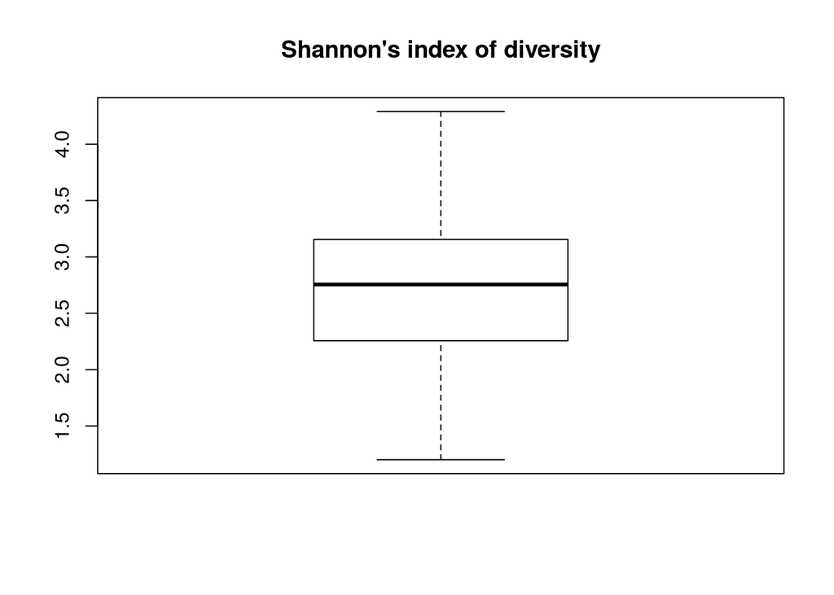

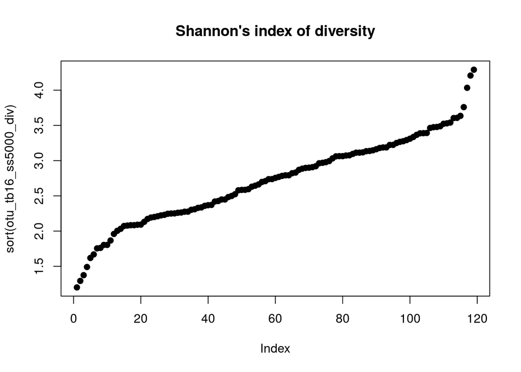

## 3.2) Richness: OTU number

Lowest number of OTUs per sample:

```
## [1] 119
```

Maximum number of OTUs per sample:

```
## [1] 342
```

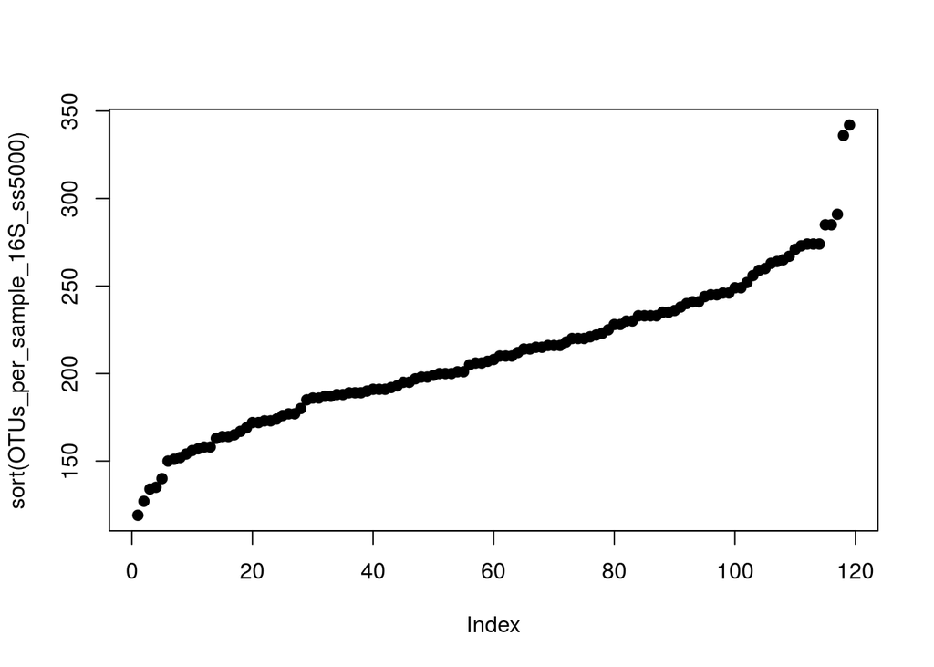

```r
plot(sort(OTUs_per_sample_16S_ss5000), pch=19)
```

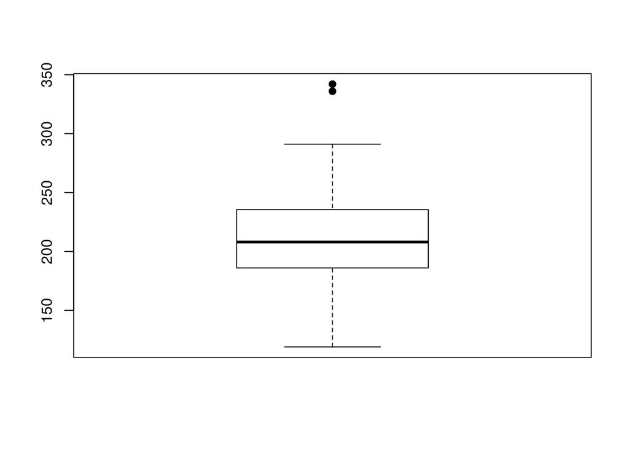

```r
boxplot(OTUs_per_sample_16S_ss5000, pch=19)
```

## 3.3) Index of evenness

### 3.3.1) Pielou’s index

```r
pielou_evenness_16S_ss5000 <- otu_tb16_ss5000_div/log(OTUs_per_sample_16S_ss5000)
```

The Pielou index (constrained between 0 and 1) takes values closer to 1 as the variation of species proportion in a sample decreases. Most of our samples get values between 0.425 and 0.6, meaning that the numerical composition of different OTUs within our samples is relatively similar:

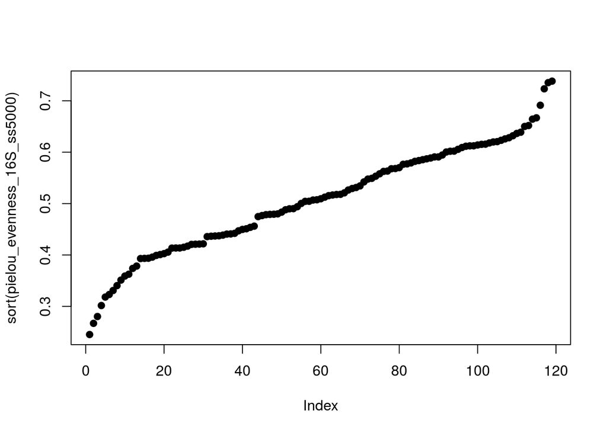

```r
plot(sort(pielou_evenness_16S_ss5000), pch=19)
```

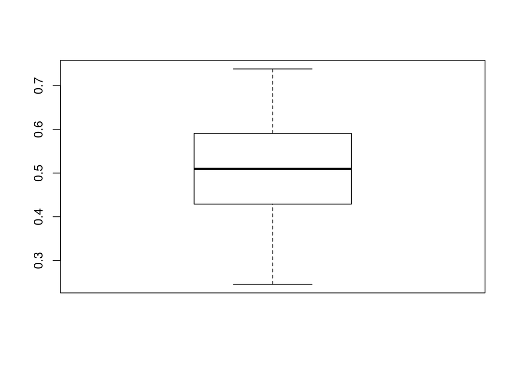

```r
boxplot(pielou_evenness_16S_ss5000, pch=19)
```

The OTU_1, with 241688 reads, is the most abundant in the overall dataset:

```r
head(sort(colSums(otu_tb16_t_ss5000_no_cero), decreasing=T), n=10L)
```

```
##   OTU_1   OTU_2   OTU_4   OTU_5   OTU_3   OTU_6 OTU_552  OTU_10  OTU_23
##  241688   85931   30188   23655   10683    9597    5973    5872    5581
## OTU_435
##    5440
```

Most of the OTUs show few occurrences, but we don’t observe the presence of a massive group of rare OTUs:

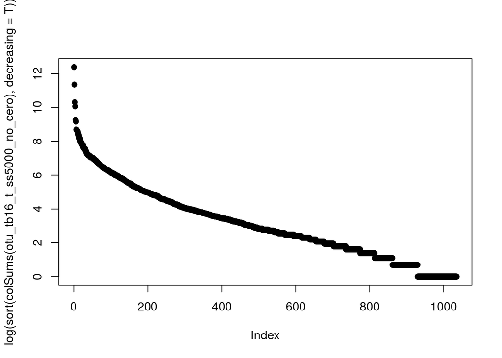

```r
plot(log(sort(colSums(otu_tb16_t_ss5000_no_cero), decreasing=T)), pch=19)
```

## 3.4) Abundance Models

### 3.4.1) Rank-Abundance or Dominance/Diversity Model (“radfit”)

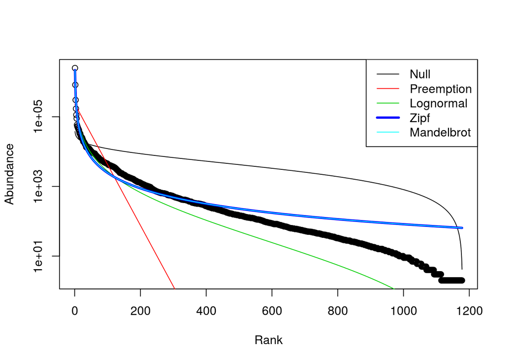

### 3.4.2) Preston’s Lognormal Model

According to Preston’s lognormal model fit into species frequencies groups, we’re missing ~59 species:

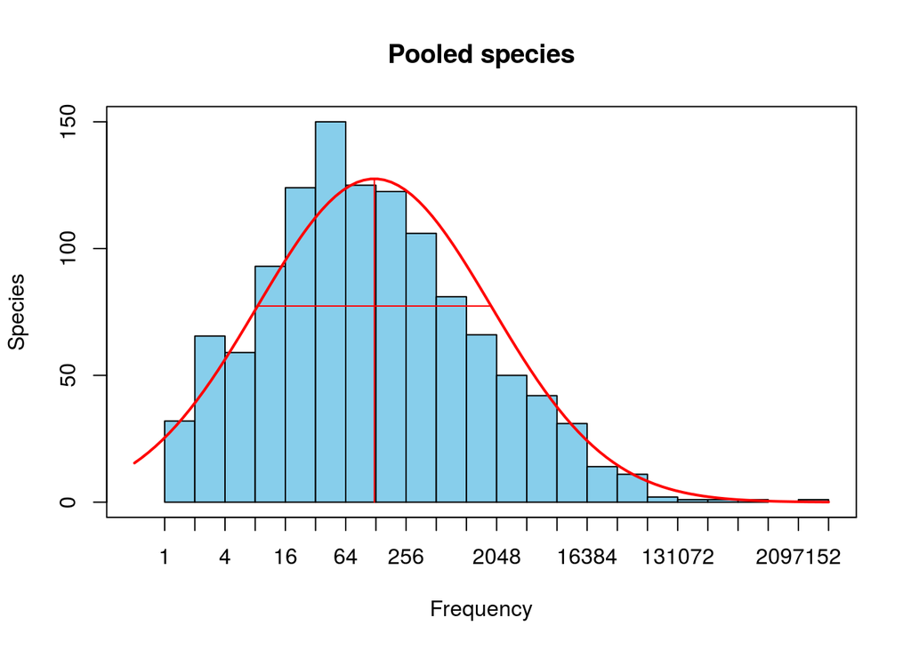

```r
otu_tb16_min5000_prestonfit<-prestonfit(colSums(otu_tb16_min5000_v2_t))
plot(otu_tb16_min5000_prestonfit, main="Pooled species")
```

```r
veiledspec(otu_tb16_min5000_prestonfit)
```

```
## Extrapolated     Observed       Veiled
##   1236.70656   1178.00000     58.70656
```

When computing Preston’s lognormal model fit without pooling data into groups, we only seem to miss ~21 species:

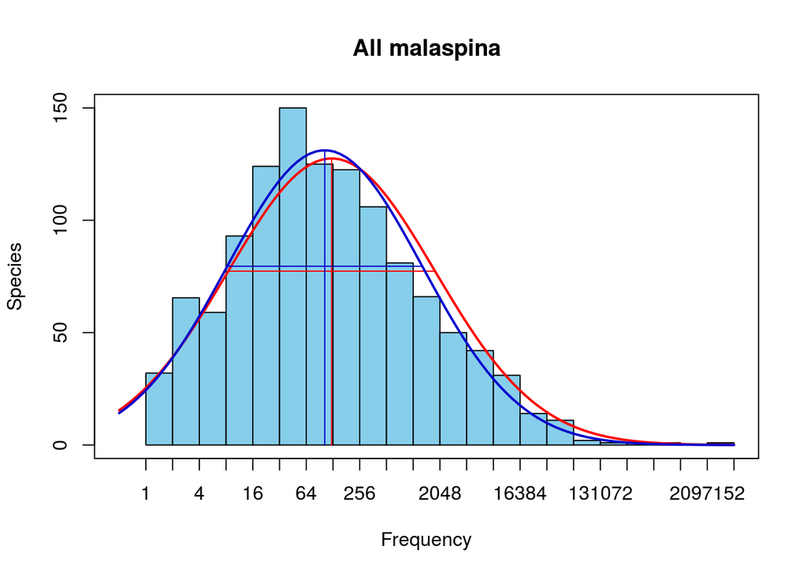

```
## Extrapolated     Observed       Veiled
##   1198.93486   1178.00000     20.93486
```

## 3.6) Beta diversity

### 3.6.1) Dissimilarity matrix using Bray-Curtis index:

The Bray-Curtis dissimilarity, constrained between 0 (minimum distance) and 1 (highest dissimilarity) allows us to quantify the differences between samples according to the composition and relative abundance of their OTUs. In our dataset, most of the samples pairs take dissimilarity values between 0.25 and 0.5, meaning that their composition is quiet similar.

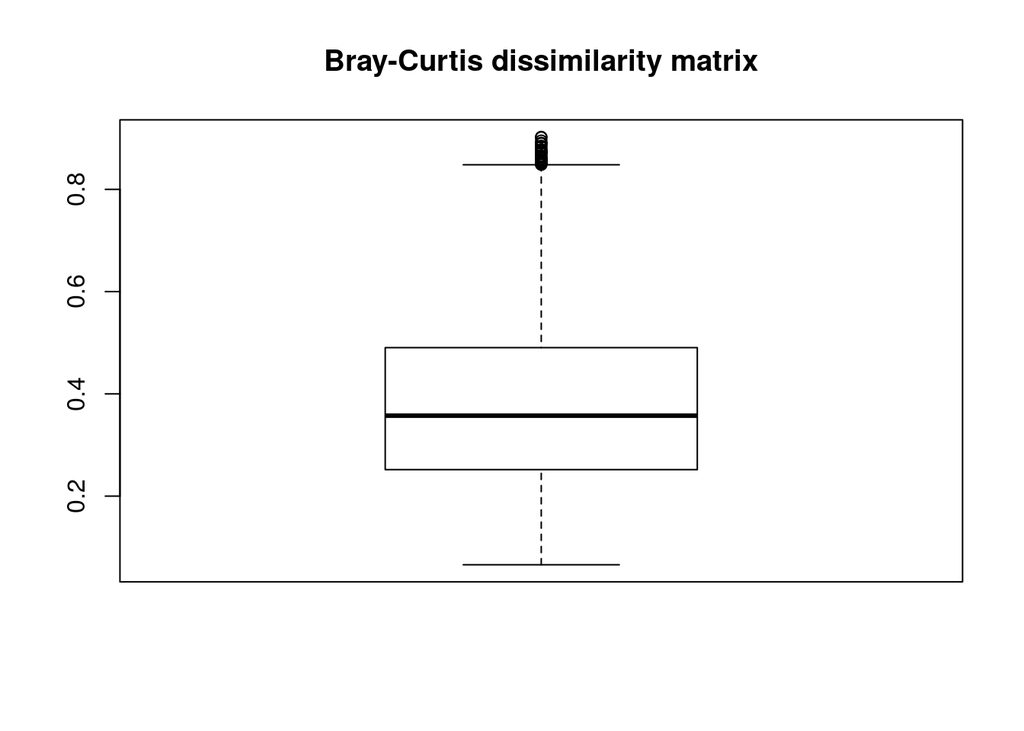

### 3.6.2) Hierarchical clustering

The only relatively evident clusters we can distinguish in the dendogram stand out in the very left side of the plot.

(To be done: assign Longhurst provinces information to each station and check if any of the central clusters is meaningful regarding to the samples’ geographical ubication)

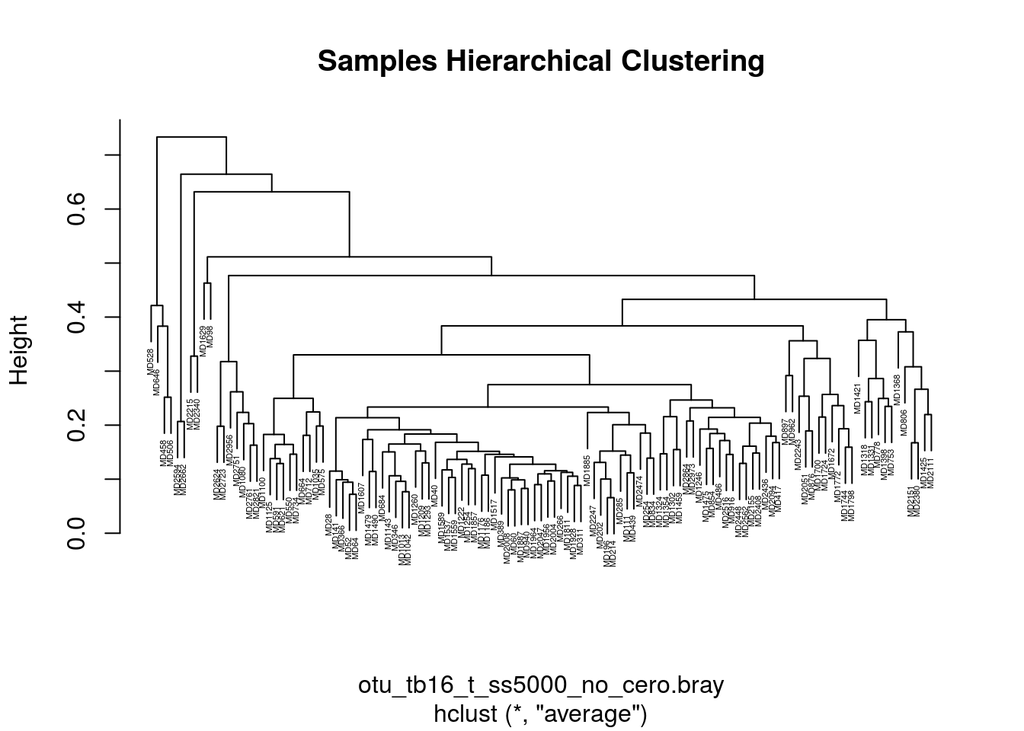

### 3.6.3) Non-metric multidimensional scaling

We can identify a prominent group in the middle-left side of the NMDS and a few isolated samples in the right edge of the plot. Considering the overall distribution, we’re not able to identify any informative clustering pattern.

The stress parameter takes a value below 0.3, meaning that the plot is valid.

```
##
## Call:
## monoMDS(dist = otu_tb16_t_ss5000_no_cero.bray)
##
## Non-metric Multidimensional Scaling
##
## 119 points, dissimilarity 'bray', call 'vegdist(x = otu_tb16_t_ss5000_no_cero, method = "bray")'
##
## Dimensions: 2
## Stress:     0.1402817
## Stress type 1, weak ties
## Scores scaled to unit root mean square, rotated to principal components
## Stopped after 98 iterations: Stress nearly unchanged (ratio > sratmax)
```

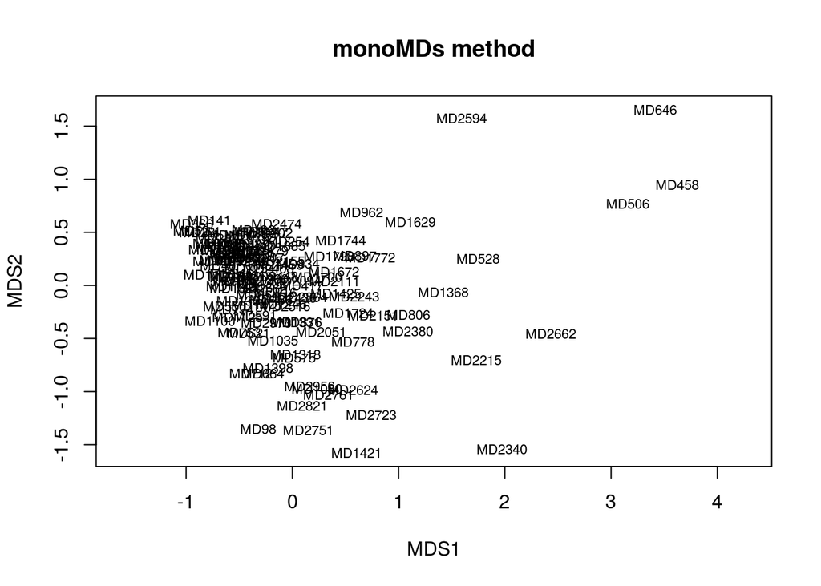

When implementing a most robut function for computing NMDS plots, the result is quiet the same:

```
## ... procrustes: rmse 0.02780627  max resid 0.2046066
## ... procrustes: rmse 0.02828654  max resid 0.203354
## ... procrustes: rmse 0.001505105  max resid 0.0119317
## ... procrustes: rmse 0.03089146  max resid 0.2069108
## ... procrustes: rmse 0.008907807  max resid 0.06705761
## ... procrustes: rmse 0.03088244  max resid 0.2068731
## ... procrustes: rmse 0.03235599  max resid 0.206803
## ... procrustes: rmse 0.02956281  max resid 0.1962803
## ... procrustes: rmse 0.006585643  max resid 0.06729219
```

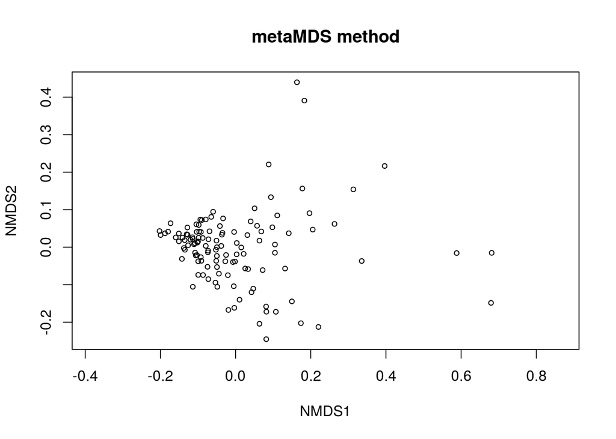

# 4) Geographical analysis

Working datasets:

1. Community matrix: otu_tb16_t_ss5000_no_cero

```r
dim(otu_tb16_t_ss5000_no_cero)
```

```
## [1]  119 1035
```

```r
otu_tb16_t_ss5000_no_cero[1:5, 1:5]
```

```
##        OTU_5 OTU_1 OTU_596 OTU_1295 OTU_36
## MD1013    43  2684       5        0     14
## MD1035    48  1589      14        0     29
## MD1042    35  2592       5        0     18
## MD1080    56   903      11        0     11
## MD1100    34  2092       9        0      1
```

2. Community Bray-Curtis: otu_tb16_t_ss5000_no_cero.bray

```r
otu_tb16_t_ss5000_no_cero.bray<-as.matrix(otu_tb16_t_ss5000_no_cero.bray)
```

3. Stations distances in km: geo_distances_MP_16S_ss5000

```r
dim(geo_distances_MP_16S_ss5000)
```

```
## [1] 119 119
```

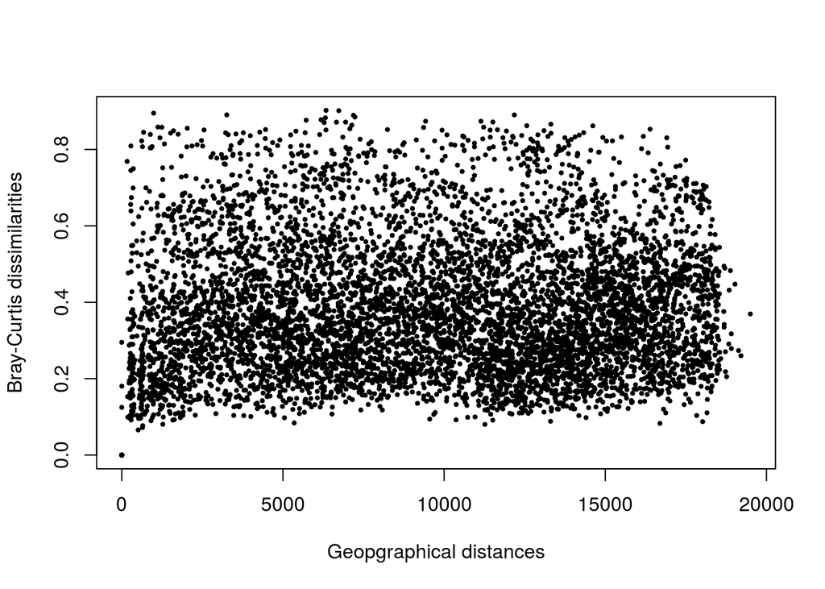

```r
plot(geo_distances_MP_16S_ss5000, otu_tb16_t_ss5000_no_cero.bray, pch=19, cex=0.4, xlab="Geopgraphical distances", ylab="Bray-Curtis dissimilarities")
```

## 4.1) Mantel correlograms

When implementing the Mantel Test, we obtain a very low statistic, meaning that the correlation between samples dissimilarity and geographical distances is weak; besides, it is not significant, so we shouldn’t consider the test meaningful.

```r
mantel(geo_distances_MP_16S_ss5000, otu_tb16_t_ss5000_no_cero.bray)
```

```
##
## Mantel statistic based on Pearson's product-moment correlation
##
## Call:
## mantel(xdis = geo_distances_MP_16S_ss5000, ydis = otu_tb16_t_ss5000_no_cero.bray)
##
## Mantel statistic r: 0.01841
##       Significance: 0.125
##
## Upper quantiles of permutations (null model):
##    90%    95%  97.5%    99%
## 0.0218 0.0303 0.0352 0.0411
## Permutation: free
## Number of permutations: 999
```

Maximum distance between samples:

```
## [1] 19500.19
```

Minimum distance between samples:

```
## [1] 0
```

Correlograms:

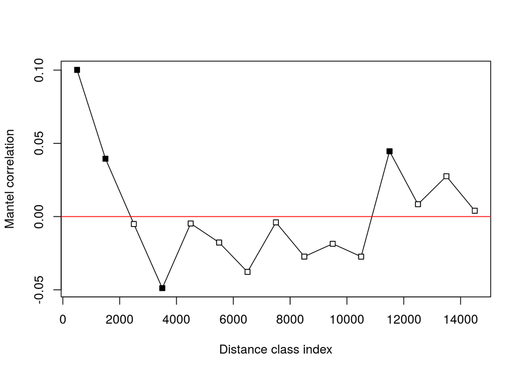

```r
MP_16s_ss5000_mantel_correl_by_1000km<-mantel.correlog(otu_tb16_t_ss5000_no_cero.bray, D.geo=geo_distances_MP_16S_ss5000, break.pts=seq(0,20000, by=1000))
plot(MP_16s_ss5000_mantel_correl_by_1000km)
```

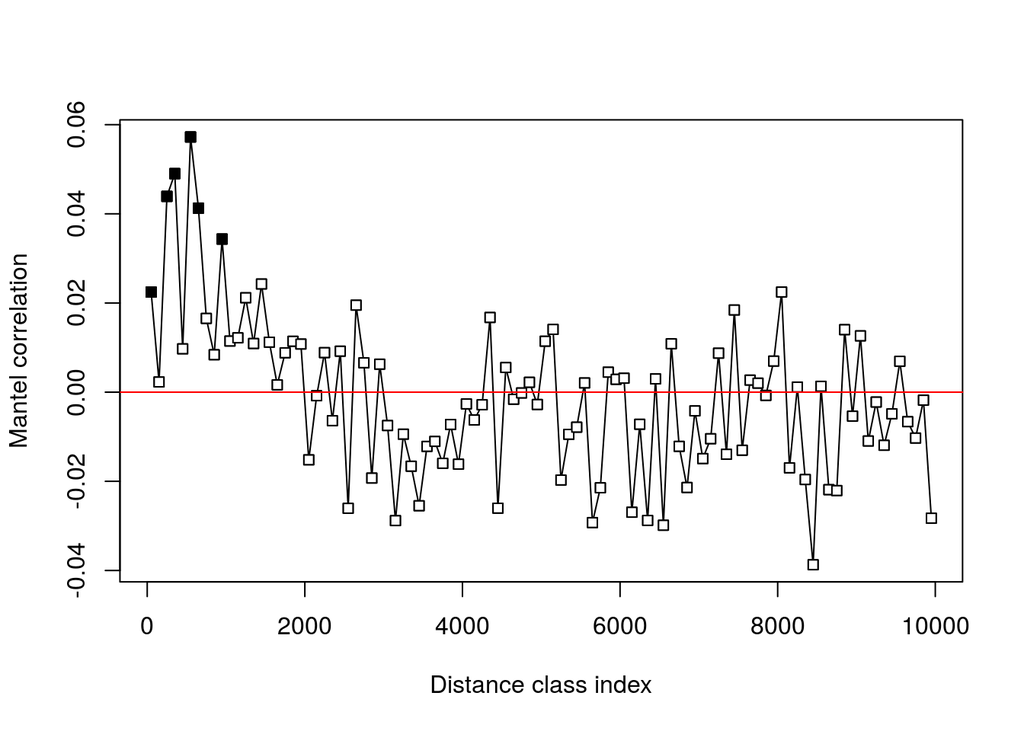

```r
MP_16s_ss5000_mantel_correl_by_100km<-mantel.correlog(otu_tb16_t_ss5000_no_cero.bray, D.geo=geo_distances_MP_16S_ss5000, break.pts=seq(0,20000, by=100))
plot(MP_16s_ss5000_mantel_correl_by_100km)
```

# 5) Abundance & occurence

In the following plot, we can appreciate the OTUs distribution according to their percentage of occurence and relative abundance. The red line keeps up OTUs that occur in more than 80% of the samples, the green line limits regionally rare OTUs (< 0.001%), and the blue one restricts regionally abundant OTUs (> 0.1%).

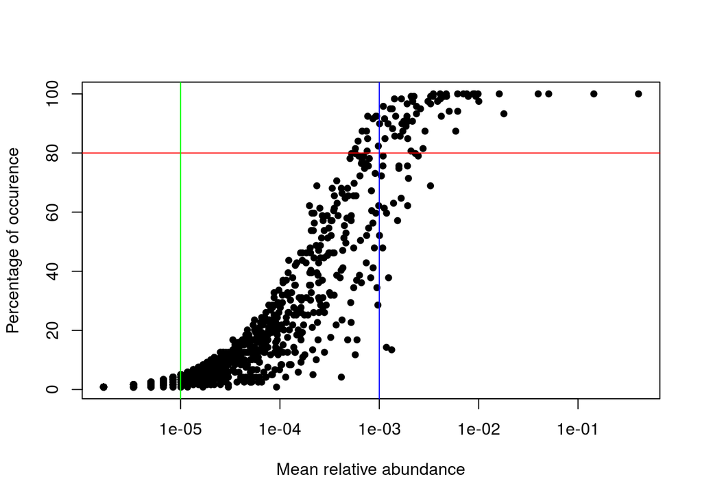

Regionally abundant OTUs (relative abundance over 0.1%):

```
##         mean_rabund perc_occur
## OTU_1   0.406198319  100.00000
## OTU_2   0.144421849  100.00000
## OTU_4   0.050736134  100.00000
## OTU_5   0.039756303  100.00000
## OTU_3   0.017954622   93.27731
## OTU_6   0.016129412  100.00000
## OTU_552 0.010038655   97.47899
## OTU_10  0.009868908  100.00000
## OTU_23  0.009379832   99.15966
## OTU_435 0.009142857  100.00000
## OTU_104 0.008803361  100.00000
## OTU_12  0.007862185   99.15966
## OTU_9   0.007605042  100.00000
## OTU_13  0.007025210  100.00000
## OTU_20  0.006156303   94.11765
## OTU_28  0.006142857  100.00000
## OTU_7   0.005884034   87.39496
## OTU_34  0.005055462   94.11765
## OTU_198 0.004752941   99.15966
## OTU_11  0.004719328  100.00000
## OTU_8   0.004505882   99.15966
## OTU_368 0.004210084   92.43697
## OTU_19  0.004124370   98.31933
## OTU_234 0.004102521  100.00000
## OTU_25  0.003862185   97.47899
## OTU_14  0.003500840  100.00000
## OTU_33  0.003477311   99.15966
## OTU_21  0.003290756   99.15966
## OTU_37  0.003287395   96.63866
## OTU_40  0.003275630   68.90756
## OTU_29  0.003092437   97.47899
## OTU_15  0.002885714   87.39496
## OTU_24  0.002757983   81.51261
## OTU_45  0.002600000   94.95798
## OTU_16  0.002465546   78.99160
## OTU_102 0.002366387   95.79832
## OTU_709 0.002366387   93.27731
## OTU_27  0.002309244   79.83193
## OTU_70  0.002235294   99.15966
```

[output cut: 30 more lines]

```
## OTU_93  0.001292437   94.95798
## OTU_31  0.001240336   37.81513
## OTU_84  0.001223529   89.91597
## OTU_46  0.001183193   59.66387
## OTU_61  0.001179832   14.28571
## OTU_98  0.001141176   84.87395
## OTU_89  0.001131092   91.59664
## OTU_74  0.001122689   61.34454
## OTU_404 0.001097479   95.79832
## OTU_103 0.001092437   78.99160
## OTU_158 0.001087395   75.63025
## OTU_52  0.001082353   47.89916
## OTU_48  0.001050420   72.26891
## OTU_147 0.001008403   89.91597
## OTU_38  0.001005042   52.10084
```

```r
dim(tb16_ss5000_abundant_sorted)
```

```
## [1] 84  2
```

Proportion of regionally abundant OTUs (%):

```
## [1] 7.381371
```

Cosmopolitan OTUs (abundance over 0.1% and occurence in more than 80% of samples):

```
##         mean_rabund perc_occur
## OTU_1   0.406198319  100.00000
## OTU_2   0.144421849  100.00000
## OTU_4   0.050736134  100.00000
## OTU_5   0.039756303  100.00000
## OTU_6   0.016129412  100.00000
## OTU_10  0.009868908  100.00000
## OTU_435 0.009142857  100.00000
## OTU_104 0.008803361  100.00000
## OTU_9   0.007605042  100.00000
## OTU_13  0.007025210  100.00000
## OTU_28  0.006142857  100.00000
## OTU_11  0.004719328  100.00000
## OTU_234 0.004102521  100.00000
## OTU_14  0.003500840  100.00000
## OTU_23  0.009379832   99.15966
## OTU_12  0.007862185   99.15966
## OTU_198 0.004752941   99.15966
## OTU_8   0.004505882   99.15966
## OTU_33  0.003477311   99.15966
## OTU_21  0.003290756   99.15966
## OTU_70  0.002235294   99.15966
## OTU_39  0.002092437   99.15966
## OTU_19  0.004124370   98.31933
## OTU_724 0.002157983   98.31933
## OTU_90  0.001670588   98.31933
## OTU_42  0.001421849   98.31933
## OTU_552 0.010038655   97.47899
## OTU_25  0.003862185   97.47899
## OTU_29  0.003092437   97.47899
## OTU_166 0.002169748   97.47899
## OTU_37  0.003287395   96.63866
## OTU_654 0.001905882   96.63866
## OTU_102 0.002366387   95.79832
## OTU_404 0.001097479   95.79832
## OTU_45  0.002600000   94.95798
## OTU_451 0.001349580   94.95798
## OTU_93  0.001292437   94.95798
## OTU_20  0.006156303   94.11765
## OTU_34  0.005055462   94.11765
```

[output cut: 9 more lines]

```
## OTU_55  0.001769748   90.75630
## OTU_69  0.001692437   89.91597
## OTU_84  0.001223529   89.91597
## OTU_147 0.001008403   89.91597
## OTU_44  0.001858824   89.07563
## OTU_62  0.001361345   88.23529
## OTU_7   0.005884034   87.39496
## OTU_15  0.002885714   87.39496
## OTU_177 0.001726050   87.39496
## OTU_41  0.001621849   85.71429
## OTU_56  0.001433613   85.71429
## OTU_35  0.001932773   84.87395
## OTU_98  0.001141176   84.87395
## OTU_24  0.002757983   81.51261
## OTU_240 0.002087395   80.67227
```

```r
dim(otu_tb16_ss5000_cosmop_sorted)
```

```
## [1] 63  2
```

Proportion of cosmopolitan OTUs (%):

```
## [1] 5.536028
```

Number and proportion (%) of rare OTUs:

```r
dim(otu_tb16_ss5000_rabund_percoccur[otu_tb16_ss5000_rabund_percoccur$mean_rabund < 0.00001 & otu_tb16_ss5000_rabund_percoccur$mean_rabund >0,])
```

```
## [1] 300   2
```

```
## [1] 26.36204
```